# practical_exercise_2, Methods 3, 2021, autumn semester

Mille Bryske

29th of September

# Assignment 1: Using mixed effects modelling to model hierarchical data

In this assignment we will be investigating the *politeness* dataset of Winter and Grawunder (2012) and apply basic methods of multilevel modelling.

## Dataset

The dataset has been shared on GitHub, so make sure that the csv-file is on your current path. Otherwise you can supply the full path.

```r
setwd("/Users/millebryske/Desktop/Uni/3. semester/Methods 3/github_methods_3/week_02")
pacman::p_load(tidyverse)

politeness <- read.csv('politeness.csv') ## read in data
politeness <- na.omit(politeness)
```

# Exercises and objectives

The objectives of the exercises of this assignment are:  
1) Learning to recognize hierarchical structures within datasets and describing them  
2) Creating simple multilevel models and assessing their fitness  
3) Write up a report about the findings of the study

REMEMBER: In your report, make sure to include code that can reproduce the answers requested in the exercises below  
REMEMBER: This assignment will be part of your final portfolio

## Exercise 1 - describing the dataset and making some initial plots

1. Describe the dataset, such that someone who happened upon this dataset could understand the variables and what they contain

The researchers are investigating whether pitch varies according to the setting a person is in - formal or informal. The experiment is performed on Koreans who now live in America. We have a dataset with 224 observations and seven coloums to describe each observation. The seven variable are: - Subject. All the matching “names” are one subject. - Gender. Pretty self-explanatory. - Scenario. The subjects are presented to seven different scenarios. - Attitude. Whether it is the formal or informal condition of the scenario. Each participant goes through both. - Total duration. Amount of time the subject uses to “complete” the scenario. - f0mn. Mean pitch (in Hz). - hiss count. Some sound might say while speaking (loud breath intakes).

````
i. Also consider whether any of the variables in _politeness_ should be encoded as factors or have the factor encoding removed. Hint: ```?factor```
````

Gender and attitude.

```r
ls.str(politeness)
```

```
## attitude :  chr [1:212] "pol" "inf" "pol" "inf" "pol" "inf" "pol" "inf" "pol" "inf" ...
## f0mn :  num [1:212] 215 211 285 266 211 ...
## gender :  chr [1:212] "F" "F" "F" "F" "F" "F" "F" "F" "F" "F" "F" "F" "F" "F" "F" ...
## hiss_count :  int [1:212] 2 0 0 0 0 0 1 0 1 0 ...
## scenario :  int [1:212] 1 1 2 2 3 3 4 4 5 5 ...
## subject :  chr [1:212] "F1" "F1" "F1" "F1" "F1" "F1" "F1" "F1" "F1" "F1" "F1" "F1" ...
## total_duration :  num [1:212] 18.39 13.55 5.22 4.25 6.79 ...
```

```r
politeness$gender <- as.factor(politeness$gender)
politeness$attitude <- as.factor(politeness$attitude)
politeness$scenario <- as.factor(politeness$scenario)
```

2. Create a new data frame that just contains the subject *F1* and run two linear models; one that expresses *f0mn* as dependent on *scenario* as an integer; and one that expresses *f0mn* as dependent on *scenario* encoded as a factor

```r
F1df1 <- politeness %>%
  filter(subject == "F1")
F1df1$scenario <- as.integer(F1df1$scenario)

F1df2 <- politeness %>%
  filter(subject == "F1")
F1df2$scenario <- as.factor(F1df2$scenario)

F1_integer <- lm(f0mn ~ scenario, F1df1)
F1_factor <- lm(f0mn ~ scenario, F1df2)
summary(F1_integer)
```

```
##
## Call:
## lm(formula = f0mn ~ scenario, data = F1df1)
##
## Residuals:
##     Min      1Q  Median      3Q     Max
## -44.836 -36.807   6.686  20.918  46.421
##
## Coefficients:
##             Estimate Std. Error t value Pr(>|t|)
## (Intercept)  262.621     20.616  12.738 2.48e-08 ***
## scenario      -6.886      4.610  -1.494    0.161
## ---
## Signif. codes:  0 '***' 0.001 '**' 0.01 '*' 0.05 '.' 0.1 ' ' 1
##
## Residual standard error: 34.5 on 12 degrees of freedom
## Multiple R-squared:  0.1568, Adjusted R-squared:  0.0865
## F-statistic: 2.231 on 1 and 12 DF,  p-value: 0.1611
```

```r
summary(F1_factor)
```

```
##
## Call:
## lm(formula = f0mn ~ scenario, data = F1df2)
##
## Residuals:
##    Min     1Q Median     3Q    Max
## -37.50 -13.86   0.00  13.86  37.50
##
## Coefficients:
##             Estimate Std. Error t value Pr(>|t|)
## (Intercept)   212.75      20.35  10.453  1.6e-05 ***
## scenario2      62.40      28.78   2.168   0.0668 .
## scenario3      35.35      28.78   1.228   0.2591
## scenario4      53.75      28.78   1.867   0.1041
## scenario5      27.30      28.78   0.948   0.3745
## scenario6      -7.55      28.78  -0.262   0.8006
## scenario7     -14.95      28.78  -0.519   0.6195
## ---
## Signif. codes:  0 '***' 0.001 '**' 0.01 '*' 0.05 '.' 0.1 ' ' 1
##
## Residual standard error: 28.78 on 7 degrees of freedom
## Multiple R-squared:  0.6576, Adjusted R-squared:  0.364
## F-statistic:  2.24 on 6 and 7 DF,  p-value: 0.1576
```

```
i. Include the model matrices, $X$ from the General Linear Model, for these two models in your report and describe the different interpretations of _scenario_ that these entail
```

```r
model.matrix(F1_integer)
```

```
##    (Intercept) scenario
## 1            1        1
## 2            1        1
## 3            1        2
## 4            1        2
## 5            1        3
## 6            1        3
## 7            1        4
## 8            1        4
## 9            1        5
## 10           1        5
## 11           1        6
## 12           1        6
## 13           1        7
## 14           1        7
## attr(,"assign")
## [1] 0 1
```

```r
model.matrix(F1_factor)
```

```
##    (Intercept) scenario2 scenario3 scenario4 scenario5 scenario6 scenario7
## 1            1         0         0         0         0         0         0
## 2            1         0         0         0         0         0         0
## 3            1         1         0         0         0         0         0
## 4            1         1         0         0         0         0         0
## 5            1         0         1         0         0         0         0
## 6            1         0         1         0         0         0         0
## 7            1         0         0         1         0         0         0
## 8            1         0         0         1         0         0         0
## 9            1         0         0         0         1         0         0
## 10           1         0         0         0         1         0         0
## 11           1         0         0         0         0         1         0
## 12           1         0         0         0         0         1         0
## 13           1         0         0         0         0         0         1
## 14           1         0         0         0         0         0         1
## attr(,"assign")
## [1] 0 1 1 1 1 1 1
## attr(,"contrasts")
## attr(,"contrasts")$scenario
## [1] "contr.treatment"
```

Interpretation when scenario is integer: Scenario is treated as something continuous that can have any value on a number scale.

Interpretation when scenario is factor: Scenario is treated as something where we have a limited set of possible values (specifically the seven scenarios we see in the data set). So a scenario either is one of the seven or not, and R gives us a TRUE/FALSE (where 1 is true and 0 is false) answer to all of the seven possibilities.

```
ii. Which coding of _scenario_, as a factor or not, is more fitting?
```

As factor.

3. Make a plot that includes a subplot for each subject that has *scenario* on the x-axis and *f0mn* on the y-axis and where points are colour coded according to *attitude*

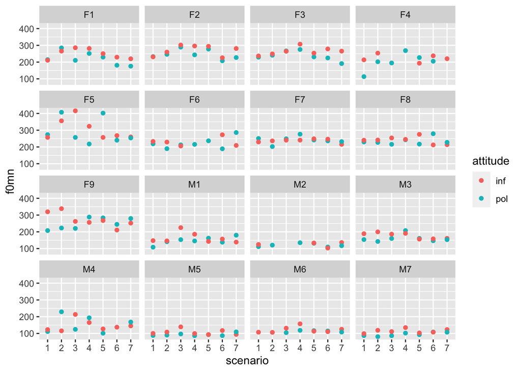

```
i. Describe the differences between subjects
```

```r
plot_allparticipants <- politeness %>%
  ggplot(aes(x = scenario, y = f0mn, color = attitude))+
  geom_point()+
  facet_wrap(~subject)
plot_allparticipants
```

Well, first of all the males have a way lower f0mn, which is very much expected. Other than that, a few of the participants vary way more in f0mn according to the scenario than others. It looks like the informal pitch is generally a liiiiittle bit higher than the formal one.